# Replication Script: Section 4 (Illustrations)

2026-10-21

# Introduction

This document provides the complete replication code for Section 4 (Illustrations) of the manuscript “postlink: An R Package for Post-Linkage Data Analysis”. It demonstrates a workflow of a secondary analyst using the `postlink` package to estimate a logistic regression model on probabilistically linked data subject to mismatch errors.

### Required Packages

```r
#install.packages("postlink_0.1.2.tar.gz", repos = NULL, type = "source")
library(dplyr)
library(tidyr)
library(ggplot2)
library(knitr)
library(kableExtra)
library(postlink)
set.seed(2026)

options(digits = 3)
```

# 1. Preliminary Steps: Record Linkage and Paradata Preparation

The secondary analyst receives only the linked dataset, which contains the variables of primary interest for the analysis. Linkage paradata may also optionally be supplied. Information on the underlying record linkage process may be limited and the individual files which were linked are not accessible.

Here, we load the `LD1000` dataset included in the `postlink` package.

```r
# Load the simulated file from a linked data provider
data("LD1000", package = "postlink")

# Sample of the linked dataset LD1000 (Table 1 in manuscript)
head(subset(LD1000, select = -c(True_Disease_Status, is_match)), n = 5)
```

```
## # A tibble: 5 × 8
##   Disease_Status   BMI   Age Treatment fl_prob safe_match    bm block_mrate
##            <int> <dbl> <int>     <int>   <dbl> <lgl>      <dbl>       <dbl>
## 1              0  26.4    33         0   0.980 FALSE         12        0.45
## 2              1  23.5    39         0   0.175 FALSE          6        0.35
## 3              1  25.1    78         0   0.981 FALSE          6        0.35
## 4              0  25.4    52         1   0.979 FALSE          3        0.25
## 5              1  27.1    40         0   0.965 FALSE          4        0.35
```

```r
LD1000$BMI <- as.numeric(scale(LD1000$BMI))
LD1000$Age <- as.numeric(scale(LD1000$Age))

# global_mismatch_rate <- 0.3
# ~ mean(LD1000$block_mrate) & 1- mean(LD1000$is_match)
```

# 2. The Benchmarks (Models 1-3)

We first establish three standard benchmark models that do not use `postlink`. The primary objective is to estimate the following logistic regression model:

```r
formula_sci <- Disease_Status ~ BMI + Age + Treatment
```

- Oracle: The unobservable gold standard, fit on the truly matched records.
- Naive (All Links): A standard logistic regression that ignores the presence of mismatches.
- Naive (Safe Matches): A model restricted only to high-confidence “safe matches”, discarding all uncertain records.

```r
# 1. Oracle: Fit on the true, perfectly linked data
fit_oracle <- glm(True_Disease_Status ~ BMI + Age + Treatment,
                  data = LD1000, family = "binomial")

# 2. Naive: Fit on all linked data, ignoring potential mismatch error
fit_naive <- glm(formula_sci,
                 data = LD1000,
                 family = "binomial")

# 3. Naive (Safe Matches): Fit only on the safe matches
fit_naive_safe <- glm(formula_sci,
                      data = subset(LD1000, safe_match == TRUE),
                      family = "binomial")
```

# 3. Aggregate Information (Model 4)

If the analyst has access to block-level mismatch rates derived from a clerical review, the `adjELE()` constructor can be used to weight the estimating equations.

```r
# Phase 1: Adjustment Specification
adj_ele_audit <- adjELE(
  linked.data = LD1000,
  m.rate = LD1000$block_mrate,
  blocks = bm,
  audit.size = rep(20, length(unique(LD1000$bm))),
  weight.matrix = "BLUE"
)
print(adj_ele_audit)
```

```
##
##  Adjustment Object: Exchangeable Linkage Errors
##
## * Linked Data:
##     Observations:   1,000
## * Specification:
##     Weight Matrix:   BLUE
##     Blocks:         12 distinct blocks
##     Mismatch Rate:  Variable (Mean: 0.271, Range: 0.100 - 0.450)
##     Audit Sample:   Same size 20
```

```r
# Phase 2: Estimation & Inference
fit_ele_audit <- plglm(
  formula = formula_sci,
  family = "binomial",
  adjustment = adj_ele_audit
)
summary(fit_ele_audit)
```

```
##
## Call:
## plglm(formula = formula_sci, family = "binomial", adjustment = adj_ele_audit)
##
## Family: binomial
##
## --- Weighting Method: BLUE ---
##             Estimate Std. Error z value Pr(>|z|)
## (Intercept)   -0.841      0.143   -5.89  3.8e-09 ***
## BMI            1.278      0.177    7.24  4.5e-13 ***
## Age            0.719      0.125    5.76  8.4e-09 ***
## Treatment     -1.526      0.264   -5.78  7.5e-09 ***
## ---
## Signif. codes:  0 '***' 0.001 '**' 0.01 '*' 0.05 '.' 0.1 ' ' 1
```

# 4. Probabilistic Paradata (Models 5-8)

When continuous or categorical linkage paradata (like match probabilities or logical indicators) are available, the EM mixture model (`adjMixture()`) can be employed to probabilistically infer the latent match status.

```r
# Model 5: EM Mixture Model (Global Rate Only)
adj_em_rate <- adjMixture(
  linked.data = LD1000,
  m.formula = ~ 1,
  m.rate = 0.3
)
print(adj_em_rate)
```

```
##
##  Adjustment Object: Mixture Model
##
## * Linked Data:
##     Observations:   1,000
## * Specification:
##     Mismatch Model:        ~1
##     Global Mismatch Rate: 0.3 (Constrained)
##     Safe Matches:         None specified
```

```r
fit_em_rate <- plglm(formula_sci, family = "binomial", adjustment = adj_em_rate)
summary(fit_em_rate)
```

```
##
## Call:
## plglm(formula = formula_sci, family = "binomial", adjustment = adj_em_rate)
##
## Outcome Model Coefficients:
##             Estimate Std. Error z value Pr(>|z|)
## (Intercept)   -0.841      0.146   -5.76  8.5e-09 ***
## BMI            1.219      0.261    4.66  3.1e-06 ***
## Age            0.713      0.141    5.05  4.4e-07 ***
## Treatment     -1.483      0.341   -4.35  1.4e-05 ***
##
## Mismatch Model Coefficients:
##             Estimate Std. Error z value Pr(>|z|)
## (Intercept)   -1.305      0.538   -2.42    0.015 *
## ---
## Signif. codes:  0 '***' 0.001 '**' 0.01 '*' 0.05 '.' 0.1 ' ' 1
##
## (Dispersion parameter for binomial family taken to be 1)
##
## Average Correct Match Probability: 0.787
```

```r
# Model 6: EM Mixture Model (Safe Matches Only)
adj_em_safe <- adjMixture(
  linked.data = LD1000,
  m.formula = ~ 1,
  safe.matches = safe_match
)
print(adj_em_safe)
```

```
##
##  Adjustment Object: Mixture Model
##
## * Linked Data:
##     Observations:   1,000
## * Specification:
##     Mismatch Model:        ~1
##     Global Mismatch Rate: Unconstrained (Estimated from data)
##     Safe Matches:         84 (8.4%)
```

```r
fit_em_safe <- plglm(formula_sci, family = "binomial", adjustment = adj_em_safe)
summary(fit_em_safe)
```

```
##
## Call:
## plglm(formula = formula_sci, family = "binomial", adjustment = adj_em_safe)
##
## Outcome Model Coefficients:
##             Estimate Std. Error z value Pr(>|z|)
## (Intercept)   -0.837      0.136   -6.16  7.4e-10 ***
## BMI            1.129      0.198    5.69  1.2e-08 ***
## Age            0.666      0.120    5.56  2.7e-08 ***
## Treatment     -1.400      0.288   -4.85  1.2e-06 ***
##
## Mismatch Model Coefficients:
##             Estimate Std. Error z value Pr(>|z|)
## (Intercept)   -1.434      0.516   -2.78   0.0054 **
## ---
## Signif. codes:  0 '***' 0.001 '**' 0.01 '*' 0.05 '.' 0.1 ' ' 1
##
## (Dispersion parameter for binomial family taken to be 1)
##
## Average Correct Match Probability: 0.824
```

```r
# Model 7: EM Mixture Model (Posterior Match Probabilities)
# Using the posterior match probabilities from the record linkage
adj_em_prob <- adjMixture(
  linked.data = LD1000,
  m.formula = ~ fl_prob
)
print(adj_em_prob)
```

```
##
##  Adjustment Object: Mixture Model
##
## * Linked Data:
##     Observations:   1,000
## * Specification:
##     Mismatch Model:        ~fl_prob
##     Global Mismatch Rate: Unconstrained (Estimated from data)
##     Safe Matches:         None specified
```

```r
fit_em_prob <- plglm(formula_sci, family = "binomial", adjustment = adj_em_prob)
summary(fit_em_prob)
```

```
##
## Call:
## plglm(formula = formula_sci, family = "binomial", adjustment = adj_em_prob)
##
## Outcome Model Coefficients:
##             Estimate Std. Error z value Pr(>|z|)
## (Intercept)   -0.858      0.138   -6.20  5.5e-10 ***
## BMI            1.131      0.131    8.64  < 2e-16 ***
## Age            0.722      0.121    5.95  2.8e-09 ***
## Treatment     -1.512      0.270   -5.61  2.0e-08 ***
##
## Mismatch Model Coefficients:
##             Estimate Std. Error z value Pr(>|z|)
## (Intercept)    0.986      0.597    1.65    0.099 .
## fl_prob       -9.281     19.490   -0.48    0.634
## ---
## Signif. codes:  0 '***' 0.001 '**' 0.01 '*' 0.05 '.' 0.1 ' ' 1
##
## (Dispersion parameter for binomial family taken to be 1)
##
## Average Correct Match Probability: 0.798
```

```r
# Model 8: EM Mixture Model (All Linkage Paradata)
adj_em_all <- adjMixture(
  linked.data = LD1000,
  m.formula = ~ fl_prob,
  safe.matches = safe_match,
  m.rate = 0.3
)
print(adj_em_all)
```

```
##
##  Adjustment Object: Mixture Model
##
## * Linked Data:
##     Observations:   1,000
## * Specification:
##     Mismatch Model:        ~fl_prob
##     Global Mismatch Rate: 0.3 (Constrained)
##     Safe Matches:         84 (8.4%)
```

```r
fit_em_all <- plglm(formula_sci, family = "binomial", adjustment = adj_em_all)
summary(fit_em_all)
```

```
##
## Call:
## plglm(formula = formula_sci, family = "binomial", adjustment = adj_em_all)
##
## Outcome Model Coefficients:
##             Estimate Std. Error z value Pr(>|z|)
## (Intercept)   -0.859      0.139   -6.19  6.2e-10 ***
## BMI            1.130      0.131    8.64  < 2e-16 ***
## Age            0.722      0.122    5.94  2.9e-09 ***
## Treatment     -1.511      0.271   -5.57  2.5e-08 ***
##
## Mismatch Model Coefficients:
##             Estimate Std. Error z value Pr(>|z|)
## (Intercept)    0.989      0.600    1.65    0.099 .
## fl_prob       -9.416     20.482   -0.46    0.646
## ---
## Signif. codes:  0 '***' 0.001 '**' 0.01 '*' 0.05 '.' 0.1 ' ' 1
##
## (Dispersion parameter for binomial family taken to be 1)
##
## Average Correct Match Probability: 0.798
```

```r
str(fit_em_all$match.prob)
```

```
##  Named num [1:1000] 1 0.447 1 1 1 ...
##  - attr(*, "names")= chr [1:1000] "1" "2" "3" "4" ...
```

# 5. Prior Knowledge (Model 9)

The Bayesian mixture framework (`adjMixBayes()`) allows the analyst to integrate historical data or domain expertise via prior distributions.

```r
round(qlogis(mean(LD1000$Disease_Status)), 2)
```

```
## [1] -1.09
```

```r
# Phase 1: Define Informative Priors
adj_bayes <- adjMixBayes(
  linked.data = LD1000,
  priors = list(
    intercept2 = "normal(-1.09, 3)",
    # Empirical log-odds of outcome prevalence
    beta2 = "normal(0, 0.01)",
    # Assume Y and X are roughly independent among non-links
    theta = "beta(70, 30)"
    # A priori expectation of a ~70% correct match rate
  )
)
print(adj_bayes)
```

```
##
##  Adjustment Object: Bayesian Mixture
##
## * Linked Data:
##     Observations:   1,000
## * Priors:
##       intercept2 : normal(-1.09, 3)
##       beta2      : normal(0, 0.01)
##       theta      : beta(70, 30)
##     (Unspecified parameters will use defaults below)
##
##     Defaults applied during fitting (for any unspecified):
##       Intercept:  intercept ~ normal(0,10)
##       GLM Slopes: beta ~ normal(0,5) [binomial: normal(0,2.5)]
##       Surv Slopes: beta ~ normal(0,5) [weibull: normal(0,2)]
##       Mix Weight:  theta ~ beta(1,1)
```

```r
# Phase 2: Posterior Sampling via MCMC
fit_bayes <- plglm(
  formula = formula_sci,
  family = "binomial",
  adjustment = adj_bayes,
  control = list(seed = 2026)
)
```

[output not shown]

```r
summary(fit_bayes)
```

```
## Call:
## plglm(formula = formula_sci, family = "binomial", adjustment = adj_bayes,
##     control = list(seed = 2026))
##
## Family:
## binomial
##
## (Component 1 = Correct-match):
## Outcome Model Coefficients:
##             Estimates Std. Error  2.5 % 97.5 %
## (Intercept)    -0.788      0.284 -1.374 -0.262
## BMI             1.412      0.252  0.963  1.951
## Age             0.805      0.169  0.504  1.170
## Treatment      -1.683      0.354 -2.448 -1.063
##
## (Component 2 = Incorrect-match):
## Outcome Model Coefficients:
##             Estimates Std. Error  2.5 % 97.5 %
## (Intercept)    -1.309      0.583 -2.599 -0.394
## BMI             0.000      0.010 -0.020  0.019
## Age             0.000      0.010 -0.018  0.019
## Treatment       0.000      0.010 -0.020  0.020
```

### Decoupling Linkage and Analysis via Multiple Imputation

Once the Bayesian model is fitted, the multiple imputation generic `mi_with()` can be used to explore alternative models of interest without rerunning the MCMC sampler.

```r
# Define an alternative exploratory model (e.g., marginal effect of Treatment)
formula_alternative <- Disease_Status ~ Treatment

# Pool the new model using the pre-computed linkage posteriors
pooled_mi_fit <- mi_with(
  object = fit_bayes,
  data = LD1000,
  formula = formula_alternative,
  family = binomial()
)
print(pooled_mi_fit)
```

```
## Pooled regression results across posterior match classifications:
##   Retained imputations (m): 9000
##
##             Estimate Std.Error CI.lwr CI.upr    df
## (Intercept)   -0.541     0.196 -0.925 -0.156 18844
## Treatment     -1.182     0.238 -1.649 -0.715 61465
```

# 6. Results Extraction and Visualization

```r
extract_model <- function(model_name, fit) {
  terms <- c("(Intercept)", "BMI", "Age", "Treatment")

  if (inherits(fit, "glmELE")) {
    est <- fit$coefficients["BLUE", terms]
    var_diag <- diag(fit$var[["BLUE"]])
    if (is.null(names(var_diag))) names(var_diag) <- colnames(fit$coefficients)
    se <- sqrt(var_diag)[terms]
  } else if (inherits(fit, "glmMixBayes")) {
    est <- colMeans(fit$estimates$coefficients)[terms]
    se <- apply(fit$estimates$coefficients, 2, sd)[terms]
  } else {
    sum_obj <- summary(fit)$coefficients
    est <- sum_obj[terms, 1]
    se <- sum_obj[terms, 2]
  }

  data.frame(Model = model_name, Term = terms,
             Estimate = as.numeric(est), SE = as.numeric(se))
}

# Compile results list
res_list <- list(
  extract_model("1. Oracle", fit_oracle),
  extract_model("2. Naive (All Links)", fit_naive),
  extract_model("3. Naive (Safe Matches Only)", fit_naive_safe),
  extract_model("4. ELE (Audit Sample)", fit_ele_audit),
  extract_model("5. EM (Global Rate)", fit_em_rate),
  extract_model("6. EM (Safe Matches Only)", fit_em_safe),
  extract_model("7. EM (Posterior Probabilities)", fit_em_prob),
  extract_model("8. EM (All)", fit_em_all),
  extract_model("9. Bayesian (Informative Priors)", fit_bayes)
)

plot_data <- bind_rows(res_list) %>%
  mutate(Conf.Low = Estimate - 1.96 * SE,
         Conf.High = Estimate + 1.96 * SE,
         Model = factor(Model, levels = rev(unique(Model))))
```

### Figure 2: fl_prob Plot

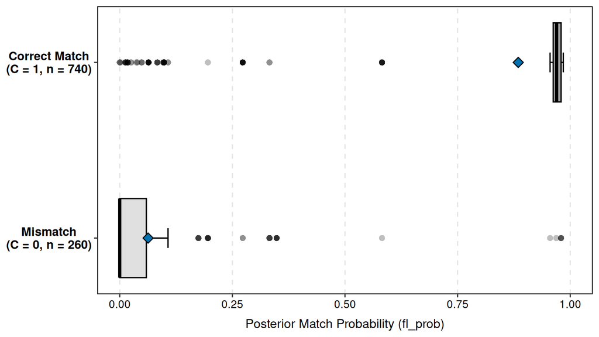

```r
label_map <- LD1000 %>%
 count(is_match) %>%
 mutate(
  label = ifelse(
   is_match,
   paste0("Correct Match\n(C = 1, n = ", n, ")"),
   paste0("Mismatch\n(C = 0, n = ", n, ")")
  )
 )
y_labels <- setNames(label_map$label, label_map$is_match)

flprob_plot <- ggplot(LD1000, aes(x = fl_prob, y = is_match, fill = is_match)) +
 geom_boxplot(
  width = 0.45,
  staplewidth = 0.25,
  color = "black",
  linewidth = 0.6,
  fatten = 2.4,
  outlier.shape = 16,
  outlier.size = 2.4,
  outlier.alpha = 0.25,
  outlier.color = "black"
 ) +
 stat_summary(
  fun = mean,
  geom = "point",
  shape = 23,
  size = 3.2,
  fill = "#0072B2",
  color = "black",
  stroke = 0.7
 ) +
 scale_fill_manual(values = c("FALSE" = "grey88", "TRUE" = "grey65")) +
 scale_y_discrete(
  labels = y_labels,
  expand = expansion(mult = c(0.32, 0.32))
 ) +
 scale_x_continuous(
  limits = c(0, 1),
  breaks = seq(0, 1, by = 0.25),
  labels = scales::number_format(accuracy = 0.01)
 ) +
 labs(
  x = "Posterior Match Probability (fl_prob)",
  y = NULL
 ) +
 theme_bw(base_size = 12, base_family = "sans") +
 theme(
  legend.position = "none",
  panel.grid.major.x = element_line(color = "grey90", linetype = "dashed"),
  panel.grid.major.y = element_blank(),
  panel.grid.minor = element_blank(),
  panel.border = element_rect(fill = NA, color = "black", linewidth = 0.8),
  axis.text.y = element_text(size = 11.5, color = "black", face = "bold", hjust = 0.5),
  axis.text.x = element_text(size = 10.5, color = "black"),
  axis.title.x = element_text(size = 12, margin = margin(t = 8))
 )

print(flprob_plot)
```

```r
ggsave("fl_prob.pdf",
       plot = flprob_plot,
       width = 7,
       height = 2.8,
       units = "in",
       device = cairo_pdf)
```

### Figure 3: Coefficient Plot

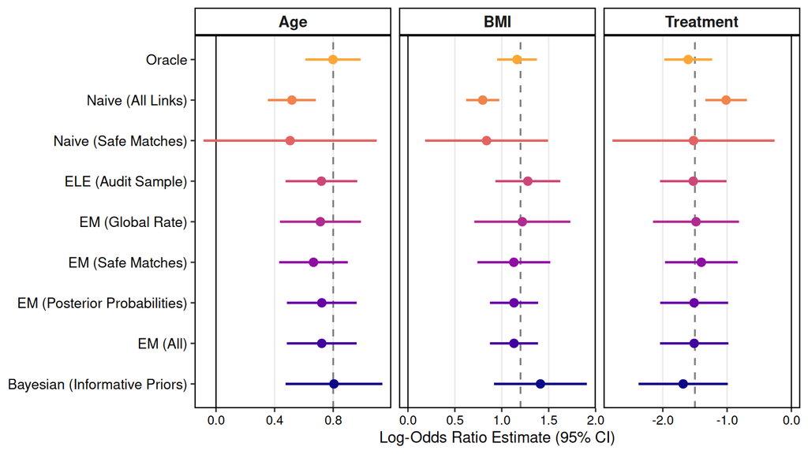

```r
clean_labels <- c(
  "1. Oracle" = "Oracle",
  "2. Naive (All Links)" = "Naive (All Links)",
  "3. Naive (Safe Matches Only)" = "Naive (Safe Matches)",
  "4. ELE (Audit Sample)" = "ELE (Audit Sample)",
  "5. EM (Global Rate)" = "EM (Global Rate)",
  "6. EM (Safe Matches Only)" = "EM (Safe Matches)",
  "7. EM (Posterior Probabilities)" = "EM (Posterior Probabilities)",
  "8. EM (All)" = "EM (All)",
  "9. Bayesian (Informative Priors)" = "Bayesian (Informative Priors)"
)

plot_data <- plot_data %>%
  mutate(Model_Clean = factor(clean_labels[as.character(Model)],
                              levels = rev(clean_labels)))

# True data-generating parameters to draw the reference dashed lines
true_lines <- data.frame(
  Term = c("BMI", "Age", "Treatment"),
  Estimate = c(1.2, 0.8, -1.5)
)

covariate_plot <- ggplot(plot_data %>% dplyr::filter(Term != "(Intercept)"),
                         aes(x = Estimate, y = Model_Clean,
                             color = Model_Clean)) +
  geom_vline(xintercept = 0, linetype = "solid", color = "black",
             linewidth = 0.4) +
  geom_vline(data = true_lines, aes(xintercept = Estimate),
             linetype = "dashed", color = "gray50", linewidth = 0.6) +
  geom_point(size = 2.5) +
  geom_errorbarh(aes(xmin = Conf.Low, xmax = Conf.High), height = 0,
                 linewidth = 0.8) +
  facet_wrap(~ Term, scales = "free_x") +
  theme_bw(base_size = 11, base_family = "sans") +
  scale_color_viridis_d(option = "plasma", end = 0.8) +
  labs(x = "Log-Odds Ratio Estimate (95% CI)", y = NULL) +
  scale_x_continuous(labels = scales::number_format(accuracy = 0.1)) +
  theme(
    legend.position = "none",
    strip.background = element_rect(fill = "white", color = "black",
                                    linewidth = 0.8),
    strip.text = element_text(face = "bold", size = 11),
    panel.grid.major.y = element_blank(),
    panel.grid.minor = element_blank(),
    panel.border = element_rect(color = "black", linewidth = 0.8),
    axis.text.y = element_text(size = 10, color = "black"),
    axis.text.x = element_text(size = 9, color = "black")
  )

print(covariate_plot)
```

```r
ggsave("covariate_plot.pdf",
       plot = covariate_plot,
       width = 8,
       height = 4.5,
       units = "in",
       device = cairo_pdf)
```

### Table 2: Summary of Estimates

```r
table_data <- plot_data %>%
  select(Model, Term, Estimate, SE) %>%
  pivot_wider(names_from = Term,
              values_from = c(Estimate, SE),
              names_glue = "{Term}_{.value}") %>%
  select(Model,
         `(Intercept)_Estimate`, `(Intercept)_SE`,
         `BMI_Estimate`, `BMI_SE`,
         `Age_Estimate`, `Age_SE`,
         `Treatment_Estimate`, `Treatment_SE`)

table_data %>%
  mutate(across(where(is.numeric), ~ sprintf("%.3f", .))) %>%
  kbl(row.names = FALSE,
      col.names = c("Model", "Est.", "SE", "Est.", "SE", "Est.",
                    "SE", "Est.", "SE"),
      align = c("l", rep("r", 8))) %>%
  add_header_above(c(" " = 1, "(Intercept)" = 2, "BMI" = 2, "Age" = 2,
                     "Treatment" = 2)) %>%
  kable_classic_2(full_width = TRUE, html_font = "sans-serif")
```

(Intercept)

BMI

Age

Treatment

Model

Est.

SE

Est.

SE

Est.

SE

Est.

SE

1. Oracle

-0.870

0.112

1.163

0.108

0.799

0.096

-1.604

0.190

2. Naive (All Links)

-0.835

0.104

0.797

0.090

0.518

0.084

-1.015

0.165

3. Naive (Safe Matches Only)

-0.855

0.380

0.838

0.334

0.506

0.302

-1.522

0.643

4. ELE (Audit Sample)

-0.841

0.143

1.278

0.177

0.719

0.125

-1.526

0.264

5. EM (Global Rate)

-0.841

0.146

1.219

0.261

0.713

0.141

-1.483

0.341

6. EM (Safe Matches Only)

-0.837

0.136

1.129

0.198

0.666

0.120

-1.400

0.288

7. EM (Posterior Probabilities)

-0.858

0.138

1.131

0.131

0.722

0.121

-1.512

0.270

8. EM (All)

-0.859

0.139

1.130

0.131

0.722

0.122

-1.511

0.271

9. Bayesian (Informative Priors)

-0.788

0.284

1.412

0.252

0.805

0.169

-1.683

0.354